# Chapter8 Summary: PART 1 - Questions 2,3 and 4

## Setup

```r
#setwd("/Users/anjali/Documents/university/Econ_5305/code_directory/Ch8_submission_full/")
rm(list = ls())
```

```r
library(openxlsx)
library(readxl)
library(ggplot2)
library(dynlm)
library(forecast)
library(urca)
library(lubridate)
library(TSstudio)
```

```r
# create a vector to store reference to all the models
model_names <- c()
model_aic <- c()
model_bic <- c()
model_cor <- c()
model_stationary <- c()
model_invertible <-c()
```

```r
store.function <- function(name = "None",this_model,DATA,stationary = TRUE,invertible = TRUE){
  model_names <<- append(model_names,name)
  model_aic <<- append(model_aic,AIC(this_model))
  model_bic <<- append(model_bic,BIC(this_model))
  this_cor <<- cor(fitted(this_model), DATA, use="pairwise.complete.obs")^2
  model_cor<<-append(model_cor,this_cor)
  model_stationary <<- append(model_stationary,stationary)
  model_invertible <<- append(model_invertible,invertible)
}
```

# Question 2

```r
excel_sheets("q2_q3_housing.xlsx")
```

```
[1] "SanDiego" "Seattle"
```

```r
data_q2 <- read_excel("q2_q3_housing.xlsx", sheet ="SanDiego")
data_q3 <- read_excel("q2_q3_housing.xlsx", sheet ="Seattle")
raw_san_diego <- ts(data_q2[ , c( "Index_NSA" )], start = c(1975, 1), frequency = 12)
raw_seattle <- ts(data_q3[ , c( "Index_NSA" )], start = c(1975, 1), frequency = 12)

# We are aggregating the index so that it is in quarterly form which is comparable to data model sample from the text book.
san_diego <- aggregate(raw_san_diego, nfrequency=4, FUN=mean)
seattle <- aggregate(raw_seattle, nfrequency=4, FUN=mean)
```

```r
cat("House Price Index - San Diego")
```

```
House Price Index - San Diego
```

```r
summary(san_diego)
```

```
   Index_NSA
 Min.   : 16.72
 1st Qu.: 48.51
 Median : 77.48
 Mean   :116.71
 3rd Qu.:180.34
 Max.   :352.76
```

```r
cat("Standard deviation: ", sd(san_diego))
```

```
Standard deviation:  80.74044
```

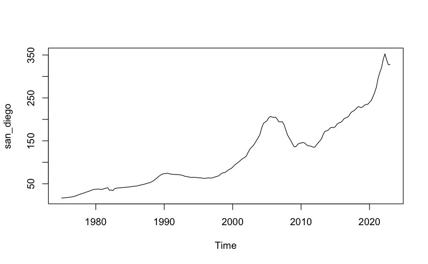

```r
ts.plot(san_diego)
```

```r
ur.df(san_diego,type="drift",lags=0)
```

```
###############################################################
# Augmented Dickey-Fuller Test Unit Root / Cointegration Test #
###############################################################

The value of the test statistic is: 3.2982 19.1342
```

**Notes:** The series has a unit root and there is a stochastic trend. It appears to be a random walk with drift. We will look at the first difference / difference(log) of the series. In the textbook section 8.3 modeling for the the house price index has been done on the Growth Function (diff(log)).

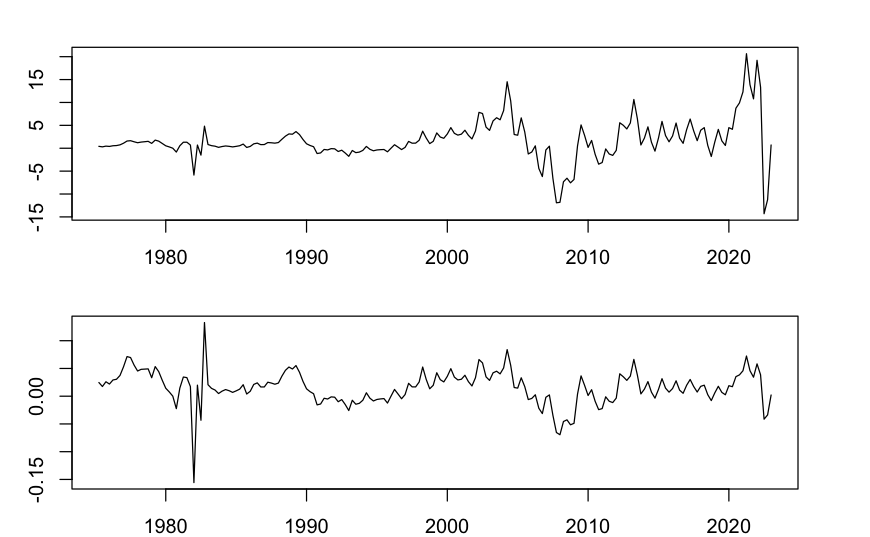

```r
d_san_diego <- diff(san_diego)
dlog_san_diego <- diff(log(san_diego))
par(mfrow=c(2,1) , mar = c(2, 3, 2, 3))
ts.plot(d_san_diego)
ts.plot(dlog_san_diego)
```

```r
ur.df(d_san_diego,type="drift",lags=0)
```

```
###############################################################
# Augmented Dickey-Fuller Test Unit Root / Cointegration Test #
###############################################################

The value of the test statistic is: -5.6363 15.8839
```

```r
ur.df(dlog_san_diego,type="drift",lags=0)
```

```
###############################################################
# Augmented Dickey-Fuller Test Unit Root / Cointegration Test #
###############################################################

The value of the test statistic is: -7.4427 27.699
```

** Notes:** Both the 1st difference and Growth Series do not have a unit root. We will do ACF and PACF analysis on the first difference + Growth series to see if the AR(4) model previously identified is still preferred. In general, we prefer the different of log rather than the difference only because it has good Interpretation, growth rate, and it helps to make the variance stationary.

```r
par(mfrow=c(2,2) , mar = c(3, 2, 3, 2))
acf(d_san_diego, main = "ACF - San Diego (1st Diff)")
pacf(d_san_diego, main = "PACF - San Diego (1st Diff)")
```

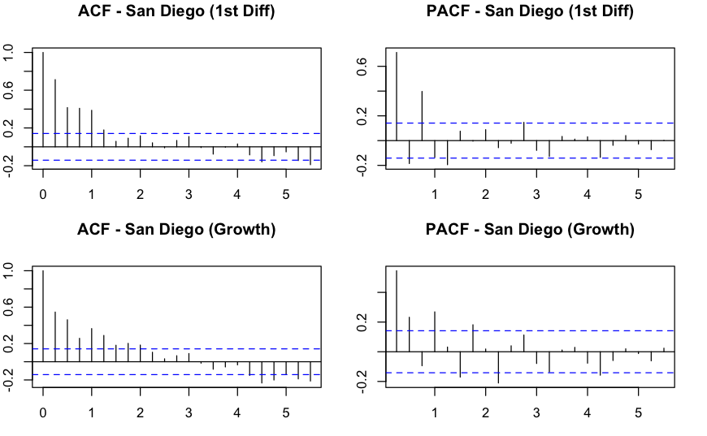

```r
acf(dlog_san_diego, main = "ACF - San Diego (Growth)")
pacf(dlog_san_diego, main = "PACF - San Diego (Growth)")
```

**Notes:** Looking at the PACF we see that there are many more prominent spikes upto 7 as compared to the model in the textbook where there are spikes only till lag = 4. The ACF and PACF here indicate AR(4) and AR(7) models for the growth series. AR(1) is marginally indicated.

```r
sandiego_AR4 <- arima(dlog_san_diego, order=c(4,0,0))
sandiego_AR4
```

```
Call:
arima(x = dlog_san_diego, order = c(4, 0, 0))

Coefficients:
         ar1     ar2      ar3     ar4  intercept
      0.4637  0.1932  -0.2095  0.2715     0.0153
s.e.  0.0694  0.0756   0.0763  0.0707     0.0059

sigma^2 estimated as 0.0005525:  log likelihood = 447.28,  aic = -882.56
```

```r
cat("\nModel R^2 =  ")
```

```
Model R^2 =
```

```r
cat(cor(fitted(sandiego_AR4),dlog_san_diego , use="pairwise.complete.obs")^2)
```

```
0.390617
```

```r
cat("\nBox Test on the Residuals:  ")
```

```
Box Test on the Residuals:
```

```r
Box.test(sandiego_AR4$residuals, type="Ljung-Box")
```

```
    Box-Ljung test

data:  sandiego_AR4$residuals
X-squared = 0.0093753, df = 1, p-value = 0.9229
```

```r
par(mfrow=c(2,2) , mar = c(3, 2, 3, 2))
plot(sandiego_AR4)
res_AR4 <- residuals(sandiego_AR4)
acf(res_AR4)
```

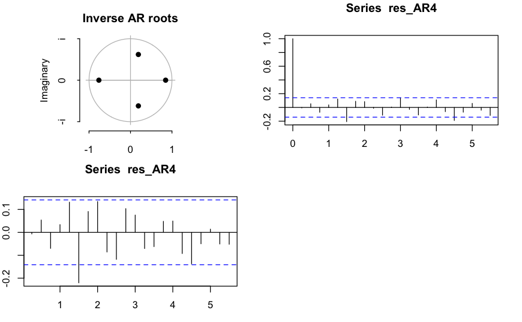

```r
pacf(res_AR4)
```

```r
sandiego_AR7 <- arima(dlog_san_diego, order=c(7,0,0))
sandiego_AR7
```

```
Call:
arima(x = dlog_san_diego, order = c(7, 0, 0))

Coefficients:
         ar1     ar2      ar3     ar4     ar5      ar6     ar7  intercept
      0.4957  0.2211  -0.3124  0.3506  0.0646  -0.2670  0.1845     0.0155
s.e.  0.0707  0.0768   0.0803  0.0796  0.0804   0.0782  0.0727     0.0061

sigma^2 estimated as 0.0005153:  log likelihood = 453.73,  aic = -889.47
```

```r
cat("\nModel R^2 =  ")
```

```
Model R^2 =
```

```r
cat(cor(fitted(sandiego_AR7),dlog_san_diego , use="pairwise.complete.obs")^2)
```

```
0.4316347
```

```r
cat("\nBox Test on the Residuals:  ")
```

```
Box Test on the Residuals:
```

```r
Box.test(sandiego_AR7$residuals, type="Ljung-Box")
```

```
    Box-Ljung test

data:  sandiego_AR7$residuals
X-squared = 0.0016312, df = 1, p-value = 0.9678
```

```r
par(mfrow=c(2,2) , mar = c(3, 2, 3, 2))
plot(sandiego_AR7)
res_AR7 <- residuals(sandiego_AR7)
acf(res_AR7)
```

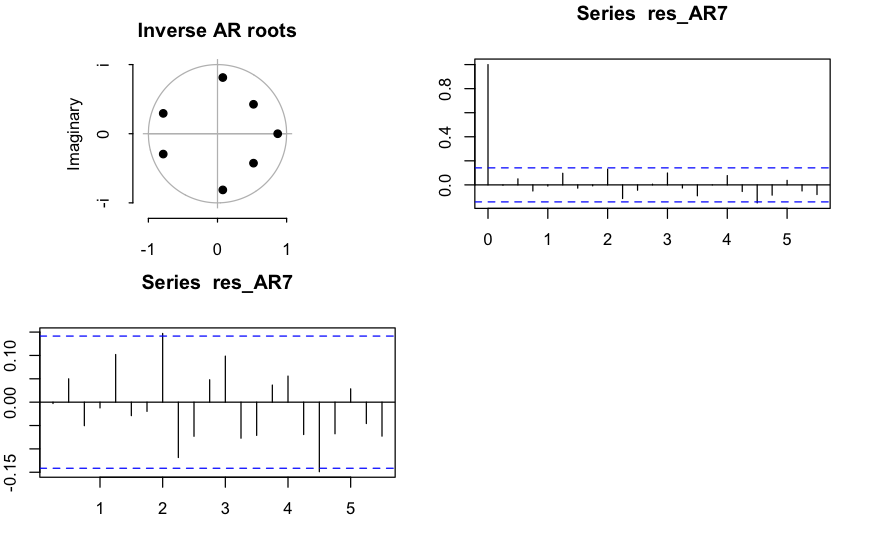

```r
pacf(res_AR7)
```

**Conclusion** The AR4 model is good but there is one spike in the ACF in the 6th lag indicating that this is not completely noise. A better model would be AR(7) model where we see no spikes in the ACF and PACF. The AR(7) model also has all invertible roots. Nevertheless we can use AR(4) model however it might not be the most preferred after updating the data. In terms of model performance - The R^2 of the model the textbook is 0.41. The AR(4) has a lower R^2 = 0.39 while the AR(7) model has R^2 = 0.43.